# Elementos determinantes en el posicionamiento de los libros en un Top-Seller

# 🤓 Resumen

Los libros son artículos que poseen una amplia variedad de autores y categorías. Por lo que, en este informe se tiene como objetivo determinar que tipo de libros se recomendarían vender, en base al autor, categoría y calificación media de este, por medio de los datos recopilados, de la página Book Depository, que poseen información detallada por libro. El análisis de los datos obtuvo como resultados que las mejores opciones a ventas son aquellas categorías que poseen muchos libros de autores en específicos que presenten una calificación media superior a 4. Sin embargo, estas respuestas pueden variar a lo largo del tiempo dependiendo de las modas. Por lo que, sería interesante tomar en cuenta en un futuro análisis, las tendencias de los compradores a lo largo de los años.

# 📒 Introducción

En los últimos años, y debido principalmente al confinamiento causado por la pandemia mundial de COVID-19, han proliferado considerablemente las ventas online de artículos de entretenimiento. Una de las categorías destacadas es la de Libros y Literatura, que registró un crecimiento del 16% en sus ventas en línea en 2020, según la empresa internacional SEMrush (Diario Uchile, 2021)

Este comercio digital proporciona información, tanto a los usuarios como a las empresas, acerca de los productos que pueden ser de interés para los compradores y que, próximamente, los vendedores expondrán en la vitrina intangible. Sin entrar mucho en detalle, como ejemplo de empresa que trabaja este formato de ventas tenemos a Book Depository. Esta empresa se destacada por su amplio catálogo de libros con envío gratuito a más de 100 países, incluido Chile. Pero ¿cómo es posible que una empresa pueda ofrecer los mismos productos a un público tan diverso? ¿Cómo sabe la empresa qué títulos y autores ofrecer?

La respuesta fue dicha previamente: transacciones. Cada compra que es realizada se registra y almacena en la base de datos de la empresa, la que se encargará de estudiar la información más relevante, como el autor o género de un libro. Con el fin de entender mejor el fenómeno que constituye un Top-Seller, en el siguiente trabajo analizaremos datos sobre el ranking de los artículos más vendidos en Book Depository, principalmente libros. Así, se espera determinar que tipo de libros se recomendarían vender, en base al autor, categoría y calificación media de este.

# 📔 Datos

En este trabajo se utilizaron las bases de datos publicadas en la página web Kaggle, facilitadas por el usuario ‘Panagiotis Simakis’, quien recopiló todos los libros registrados en la página Book Depository en un total de 5 tablas, donde 4 son únicamente llaves, respecto a la principal.

La primera es dataset.csv, que contiene 28 columnas con información detallada con respecto a los artículos ofrecidos por la página.(Title, author, isbn, id, rating-avg, etc.)

La segunda, authors.csv, contiene 2 columnas: ID y el respectivo Nombre del Autor.

La tercera, categories.csv, contiene 2 columnas: ID y el respectivo Nombre de la Categoría (Adult, Fantasy, Manga, etc.)

La cuarta tabla se llama formats.csv y contiene 2 columnas: ID y el respectivo formato (Book, CD, Audio, etc.)

La quinta tabla, places.csv, posee 2 columnas: ID y el respectivo lugar de publicación.

La sexta tabla, datos_finales.csv, es el resultado del pre-procesamiento de dataset.csv.

Por último, en función de estos datos, se busca responder las siguientes interrogantes:

1. ¿Quiénes son los autores de los primeros 10 Top-Seller en Book Depository?
2. Estos autores ¿qué valoraciones tienen?
3. ¿Cuáles son las 10 categorías más vendidas?
4. ¿Qué relación existe entre los autores Top-Seller y dichas categorías?
5. ¿Existe algún autor, especializado en alguna de las 10 categorías principales y que posea un libro entre los 10.000 Top-Seller , con un rating_avg = 5 ?

# 📙 Materiales y métodos

Para contestar las preguntas planteadas anteriormente se utilizaron las tablas que se encuentran detalladas al final de esta página.

Particularmente, como pre-procesamiento, se modificaron los datos de la tabla dataset, dado a su gran tamaño. Para ello, se importaron los datos a RStudio y se utilizó la librería Tidyverse, que facilitó algunas funciones para conseguir el objetivo.

Una vez importados los datos, se eliminaron todos los registros de los libros que no pertenecían al top 10.000 Best-Seller de Book Depository y aquellos que tuvieran datos faltantes (NA) Luego, se seleccionaron sólo las columnas de utilidad y se guardaron en el archivo llamado datos_finales.csv.

### Dataset

Contiene 28 columnas con información detallada con respecto a los artículos ofrecidos por la página.

| Variable | Contenido |
| --- | --- |
| authors: | ID-Autor(es) (lista de str) |
| bestsellers-rank: | ID-Ranking de los artículos más vendidos (int) |
| categories: | ID-Categorías. (lista de str) |
| description: | Descripción (str) |
| dimension-x: | Dimensión X (float en cm) |
| dimension-y: | Dimensión Y (float en cm) |
| dimension-z: | Dimensión Z (float en cm) |
| edition: | Edición (str) |
| edition-statement: | Declaración de edición (str) |
| for-ages: | Rango de edades (str) |
| format: | ID-Formato. (int) |
| id: | Identificador único (int) |
| illustrations-note: | Sin información registrada |
| image-checksum: | Suma de comprobación de la imagen de portada |
| image-path: | Ruta del archivo de la imagen de portada |
| image-url: | URL de la imagen de portada |
| imprint: | No hay información registrada |
| index-date: | Fecha de rastreo (date) |
| isbn10: | ISBN-10 (str) |
| isbn13: | ISBN-13 (str) |
| lang: | Idioma del artículo de la página |
| publication-date: | Fecha de publicación (date) |
| publication-place: | ID-Lugar de publicación (int) |
| rating-avg: | Calificación promedio 0-5 |
| rating-count: | Número de calificaciones |
| title: | Título del libro (str) |
| url: | URL relativa ( https://bookdepository.com + url) |
| weight: | Peso (en kg) |

### Authors

Contiene 2 columnas:

| Variable | Contenido |
| --- | --- |
| author_id: | ID-Autor (int) |
| author_name: | Nombre del autor correspondiente al ID (str) |

### Categories

| Variable | Contenido |
| --- | --- |
| category_id: | ID-Categoría (int) |
| category_name: | Nombre de la categoría correspondiente al ID (str) |

### Formats

Contiene 2 columnas:

| Variable | Contenido |
| --- | --- |
| format_id: | ID-Formato (int) |
| format_name: | Nombre del formato correspondiente al ID (str) |

### Places

Contiene 2 columas:

| Variable | Contenido |
| --- | --- |
| place_id: | Sin información |
| place_name: | Sin información |

### Datos Finales

Tal como se mencionó en Datos, datos_finales.csv es el resultado del pre-procesamiento de dataset.csv, que se puede ver en detalle en el siguiente [enlace](https://github.com/Marie-TB/LET/blob/179f182fbe4e9a1139e26b472e56fc3c0ab97b91/Codigos/Modificacion%20datos,%20graficos%20y%20tablas.R)

| Variable | Contenido |
| --- | --- |
| authors: | ID-Autor(es) (lista de str) |
| bestsellers_rank: | ID-Ranking de los artículos más vendidos (int) |
| categories | ID-Categorías. (lista de str) |
| format | ID-Formato. (int) |
| id | Identificador único (int) |
| lang | Idioma del artículo |
| rating_avg | Calificación promedio 0-5 |
| title | Título del libro (str) |

# 📘 Análisis

Cada persona tiene gustos propios y estos no tienen por qué ser idénticos a los del resto. Sin embargo, esto no significa que no existan preferencias en común. Como consecuencia, cuando existen muchas personas con una misma inclinación, se generan tendencias y, en el caso de los libros, se ven reflejadas en los Top-Seller. Por este motivo, para entender el posicionamiento de libros en base al autor y categoría de estos, se responderá la pregunta “¿Quiénes son los autores de los 10 libros Top-Seller en Book Depository?”, con el siguiente gráfico de barras:

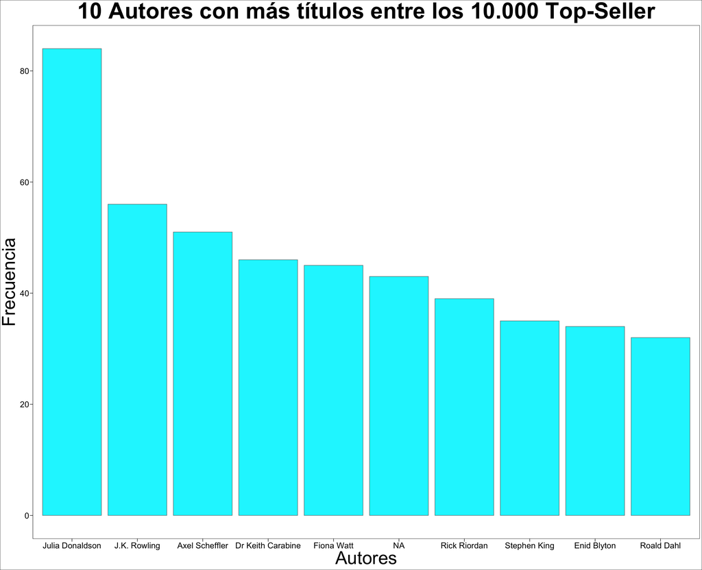

Se puede observar que, quien posee más libros entre los 10.000 Top-Seller es la autora inglesa Julia Donaldson; famosa por sus libros ilustrados para infantes, como la serie literaria “El Grúfalo”. Tras ella, se encuentra J.K. Rowling, autora famosa por su saga juvenil de fantasía “Harry Potter” con sus múltiples ediciones especiales por aniversarios. También se aprecia que, hay una cantidad no menor de libros que poseen como autor “NA”. Esto significa que, a esos 43 libros no se les registró el autor en los datos.

En base a lo anterior, se genera la segunda interrogante planteada en la presentación de los datos, que es: ¿qué valoraciones tienen dichos autores? Para resolverla, se tomó las calificaciones de la base de datos, que poseen un rango del 0 al 5, donde 5 es la mejor valoración. Luego, se promedió por autor y se resumió en la siguiente tabla:

| Autores | Calificacion |
| --- | --- |
| J.K. Rowling | 4.5 |
| Rick Riordan | 4.4 |
| Enid Blyton | 4.3 |
| NA | 4.2 |
| Julia Donaldson | 4.2 |
| Fiona Watt | 4.2 |
| Axel Scheffler | 4.2 |
| Stephen King | 4.1 |
| Roald Dahl | 4.1 |
| Dr Keith Carabine | 3.9 |

Se puede apreciar que, en este caso, J.K.Rowling lidera con una calificación media de 4.5, seguida por Rick Riordan con un 4.4. Sin embargo, este último se encontraba en séptimo lugar en el gráfico anterior. Caso contrario a Julia Donaldson que, en base a la calificación, descendió hasta el quinto puesto; pese a presentar más libros dentro de los Top-Seller.

Puesto que, la calificación fue otorgada al libro, es de suma importancia analizar los autores de este, en conjunto con la categoría, lo que implica contestar la tercera y cuarta pregunta: “¿Cuáles son las 10 categorías más vendidas?” y “¿qué relación existe entre los autores Top-Seller y dichas categorías?” Para contestar la primera interrogante, se realizó el siguiente gráfico con las 10 primeras categorías Top-Seller:

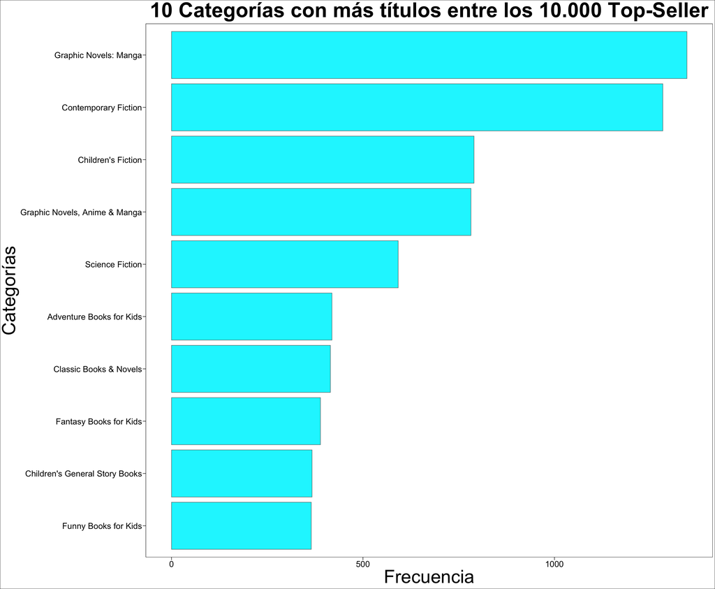

Se puede notar que, existen dos categorías que se pueden fusionar (*Graphic Novels: Manga* y *Graphic Novels: Anime & Manga* ), provocando que esta unión lidere el Top-Seller, tal como se aprecia en el siguiente gráfico:

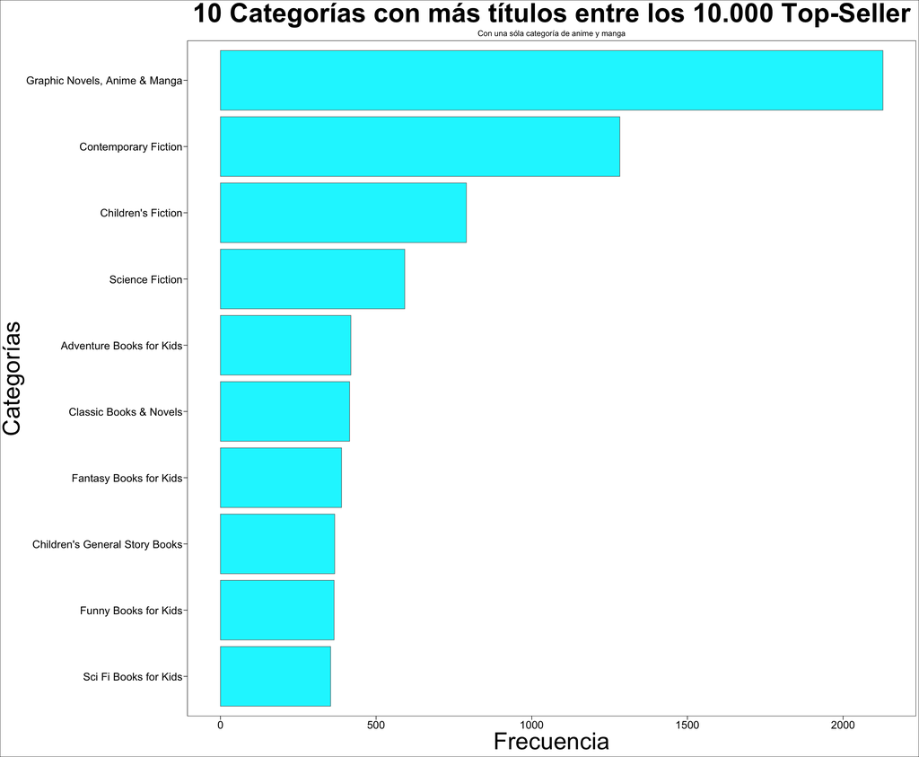

Las dos figuras anteriores muestran que, existe una tendencia muy marcada, en comparación con los autores, en las preferencias de categorías literarias, donde lideran *Graphic Novels: Anime & Manga* y *Contemporary Fiction* con más de 1000 libros cada uno. Luego, si se comparan las frecuencias de estas con las frecuencias de los autores más populares, se puede cuestionar la existencia de una relación entre ellos, es decir, se pone en duda que los 10 autores del Top-Seller escriben libros clasificados en las categorías vistas en el gráfico, debido a que, si se suman todas las frecuencias de los autores (465 en total), no tienen comparación con la frecuencia total de las 10 categorías juntas (6748), evidenciando la diferencia de libros considerados entre el análisis de autores y categorías.

El cuestionamiento anterior, es el motivo de la pregunta “¿qué relación existe entre los autores Top-Seller y dichas categorías?”, mencionada anteriormente. Para responderla, se realizó el siguiente gráfico que contiene las categorías, según los autores del Top-Seller.

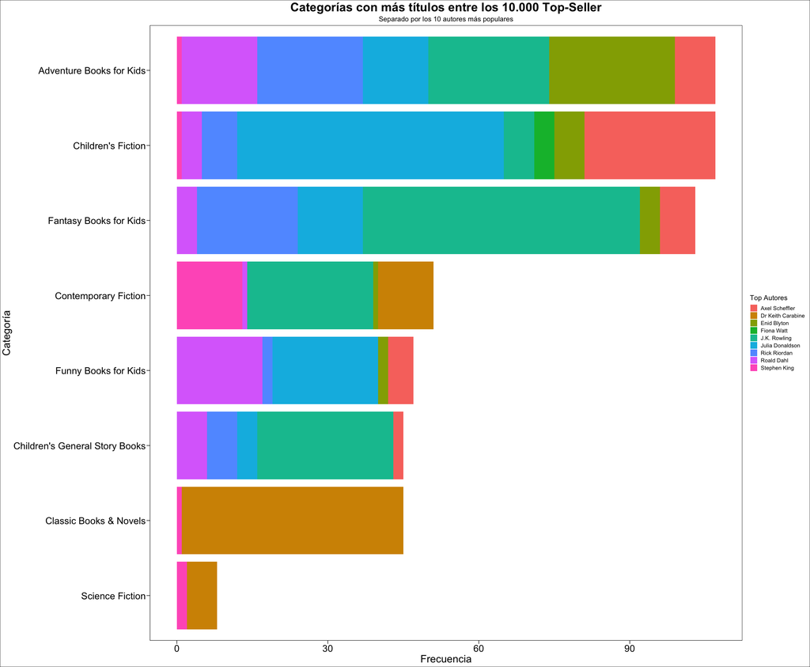

Se puede observar que, al intersectar las categorías con los autores, desaparecen *Graphic Novels: Anime & Manga* y *Sci Fi Books for Kids*. Esto se debe a que ninguno de los 10 principales autores es dueño de algún libro clasificado en esas categorías. Sin embargo, se observa el caso contrario con algunos escritores, es decir, poseen muchos libros en una categoría. Por ejemplo, J.K. Rowling en *Fantasy Books for Kids*.

En consecuencia, se puede insinuar que existe una especialización de J.K. Rowling en dicha categoría, provocando que ella posea un promedio alto en rating_avg. Por este motivo, se decidió mostrar los autores que poseían una media de calificación perfecta (5) en al menos uno de sus libros, pertenecientes a las 10 categorías principales del Top-Seller.

| title | category_name | author_name | rating_avg |
| --- | --- | --- | --- |
| Transient Desires | Contemporary Fiction | Donna Leon | 5 |
| Sometimes I Am Angry | Children's Fiction | Marie Paruit | 5 |
| In Another World With My Smartphone: Volume 14 | Graphic Novels: Manga | Eiji Usatsuka | 5 |
| Trinity Seven, Vol. 22 | Graphic Novels: Manga | Akinari Nao | 5 |
| Aria: The Masterpiece, Volume 7 | Science Fiction | Kozue Amano | 5 |
| Conan Chronicles Epic Collection: The Song Of Belit | Graphic Novels, Anime & Manga | Becky Cloonan | 5 |
| The Light at the Edge of the World and Other Stories | Science Fiction | L M Merrington | 5 |
| Purgatory Mount | Science Fiction | Adam Roberts | 5 |
| The Adventure Zone: The Crystal Kingdom | Graphic Novels, Anime & Manga | Clint McElroy | 5 |
| Doctor Who: Dalek (Target Collection) | Science Fiction | Robert Shearman | 5 |
| Sunstone, Volume 7 | Graphic Novels, Anime & Manga | Stjepan Sejic | 5 |
| The Collected Stories of Shirley Hazzard | Contemporary Fiction | Shirley Hazzard | 5 |
| Welsh Fairy Tales, Myths and Legends | Children's Fiction | Claire Fayers | 5 |
| Harry Potter and the Half-Blood Prince - Slytherin Edition | Contemporary Fiction | J.K. Rowling | 5 |
| My First Bedtime Stories | Children's Fiction | Nicola Baxter | 5 |
| Room on the Broom: A Push, Pull and Slide Book | Children's Fiction | Axel Scheffler | 5 |
| Thomas & Friends: James | Children's Fiction | Rev. W. Awdry | 5 |
| Mr. Men in Ireland | Funny Books for Kids | Adam Hargreaves | 5 |
| Ultimate Sticker Book: Winnie the Pooh | Children's Fiction | DK | 5 |
| DOG MAN 1-6 HB TOY CAT | Funny Books for Kids | Dav Pilkey | 5 |
| Complete Chester Gould's Dick Tracy Volume 29 | Graphic Novels, Anime & Manga | Chester Gould | 5 |
| Foxes in Love : Volume 1 | Graphic Novels, Anime & Manga | Toivo Kaartinen | 5 |

Se puede observar que, en la columna de author_name hay muchas personas que consiguieron una puntuación perfecta en sus libros, pero no son parte de los 10 autores con más libros entre los Top-Seller de la página. Por lo tanto, se realizó un filtro en base a ese criterio, logrando contestar la última pregunta: “¿Existe algún autor, especializado en alguna de las 10 categorías principales y que posea un libro entre los 10.000 Top-Seller , con un rating_avg = 5 ?”

| title | category_name | author_name | rating_avg |
| --- | --- | --- | --- |
| Harry Potter and the Half-Blood Prince - Slytherin Edition | Contemporary Fiction | J.K. Rowling | 5 |
| Room on the Broom: A Push, Pull and Slide Book | Children's Fiction | Axel Scheffler | 5 |

Por último, se puede apreciar que, J.K. Rowling obtuvo un rating_avg = 5 en uno de sus libros pertenecientes a la categoría *Contemporary Fiction* que **no** es la misma clasificación que se le asumió la existencia de una especialización por parte de la autora. También se observa que, el autor Axel Scheffler obtuvo una puntuación perfecta, pese a que él posee una variedad de clasificaciones, con respecto a las categorías, de sus libros; tales como *Adventure Books for Kids*, *Children’s Fiction*, *Fantasy Books for Kids*, entre otros.

# 📓 Conclusión

Según las respuestas encontradas, se concluye que las mejores opciones a ventas son aquellas categorías que poseen muchos libros de autores en específicos que presenten un rating_avg superior a 4, ya que estos duplican, por lo menos, la cantidad de Top-Sellers del resto de libros pertenecientes a otras categorías. También se puede concluir que, otras opciones de ventas son aquellos libros clasificados como *Graphic Novels: Anime & Manga* y *Contemporany fiction*, sí o sólo sí, existe una variedad de autores, dado a que son las categorías que más libros poseen dentro del Top-Seller de Book Depository y, además, varios títulos presentan una calificación perfecta de rating-avg. Por lo tanto, estos resultados evidencian que los mejores tipos de libros para vender son aquellos que pertenezcan a las últimas dos categorías mencionadas y, también, aquellos que se clasifiquen como *Adventure Books for kids*, *Children’s Fiction* y *Fantasy Books for Kids* de los autores J.K Rowling, Julia Donaldson, Rick Riordan y Axel Scheffler, dado a que presentan excelentes calificaciones promedio y son los autores que poseen más libros en esas categorías principales.

Como consecuencia, estos resultados van a variar en el tiempo gracias a las modas temporales, puesto a que las respuestas están basadas en las frecuencias de las ventas de libros de ciertas características, por lo que sería interesante tomar en cuenta, en un futuro análisis, las tendencias a lo largo de los años y los factores sociales de los compradores, para obtener mejores resultados.

# 🖊 Referencias

1. Diario Uchile. (2020, 10 junio). *Librerías se reactivan frente a la pandemia: serán consideradas como “bien esencial”*. Recuperado 20 de septiembre de 2021, de https://radio.uchile.cl/2020/06/10/librerias-se-reactivan-frente-a-la-pandemia-seran-consideradas-como-bien-esencial/
2. Panagiotis, S. (2021, agosto). *Conjunto de datos de Book Depository*. Kaggle. https://www.kaggle.com/sp1thas/book-depository-dataset?select=dataset.csv
3. Wickham et al., (2019). *Welcome to the tidyverse*. Journal of Open Source Software, 4(43), 1686, https://doi.org/10.21105/joss.01686
4. Hadley Wickham and Jim Hester (2021). *readr: Read Rectangular Text Data.* R package version 2.0.1. https://CRAN.R-project.org/package=readr
5. Hadley Wickham, Romain François, Lionel Henry and Kirill Müller (2021). *dplyr: A Grammar of Data Manipulation*. R package version 1.0.7. https://CRAN.R-project.org/package=dplyr
6. Hadley Wickham (2021). *tidyr: Tidy Messy Data*. R package version 1.1.3. https://CRAN.R-project.org/package=tidyr
7. Lionel Henry and Hadley Wickham (2020). *purrr: Functional Programming Tools*. R package version 0.3.4. https://CRAN.R-project.org/package=purrr
8. Sam Firke (2021). *janitor: Simple Tools for Examining and Cleaning Dirty Data*. R package version 2.1.0. https://CRAN.R-project.org/package=janitor
9. Hadley Wickham (2019). *stringr: Simple, Consistent Wrappers for Common String Operations*. R package version 1.4.0. https://CRAN.R-project.org/package=stringr
10. H. Wickham. *ggplot2: Elegant Graphics for Data Analysis*. Springer-Verlag New York, 2016.
11. Richard Iannone, Joe Cheng and Barret Schloerke (2021). *gt: Easily Create Presentation-Ready Display Tables*. R package version 0.3.1. https://CRAN.R-project.org/package=gt
12. Hadley Wickham (2021). *forcats: Tools for Working with Categorical Variables (Factors)*. R package version 0.5.1. https://CRAN.R-project.org/package=forcats
13. Hadley Wickham, Romain François and Lucy D’Agostino McGowan (2021). *emo: Easily Insert ‘Emoji’*. R package version 0.0.0.9000. https://github.com/hadley/emo
14. Kirill Müller (2020). *here: A Simpler Way to Find Your Files*. R package version 1.0.1. https://CRAN.R-project.org/package=here